# FordGoBike (Communicate Data Findings Project)

## Introduction

This dataset contains bike sharing information posted in the month of April by Bay Wheels, formerly known as FordGoBike. This data set contains approximately 239,000 individual entries of users posting their data regarding their bike rides.

```python
## Importing necessary Packages for Visualization
import numpy as np
import pandas as pd
import matplotlib.pyplot as plt
import seaborn as sns
%matplotlib inline
```

## Data Wrangling

```python
df = pd.read_csv('201904-fordgobike-tripdata.csv')
df.head()
```

|  | duration_sec | start_time | end_time | start_station_id | start_station_name | start_station_latitude | start_station_longitude | end_station_id | end_station_name | end_station_latitude | end_station_longitude | bike_id | user_type | bike_share_for_all_trip |
| --- | --- | --- | --- | --- | --- | --- | --- | --- | --- | --- | --- | --- | --- | --- |
| 0 | 50305 | 2019-04-30 22:33:55.1550 | 2019-05-01 12:32:20.4540 | 368.0 | Myrtle St at Polk St | 37.785434 | -122.419622 | 324.0 | Union Square (Powell St at Post St) | 37.788300 | -122.408531 | 2749 | Subscriber | No |
| 1 | 53725 | 2019-04-30 20:43:41.6320 | 2019-05-01 11:39:06.9170 | 246.0 | Berkeley Civic Center | 37.869060 | -122.270556 | 241.0 | Ashby BART Station | 37.852477 | -122.270213 | 2608 | Customer | No |
| 2 | 78072 | 2019-04-30 10:32:46.4890 | 2019-05-01 08:13:58.9750 | 64.0 | 5th St at Brannan St | 37.776754 | -122.399018 | 64.0 | 5th St at Brannan St | 37.776754 | -122.399018 | 258 | Subscriber | No |
| 3 | 78969 | 2019-04-30 10:00:51.5500 | 2019-05-01 07:57:01.2620 | 67.0 | San Francisco Caltrain Station 2 (Townsend St... | 37.776639 | -122.395526 | 89.0 | Division St at Potrero Ave | 37.769218 | -122.407646 | 1974 | Subscriber | No |
| 4 | 1128 | 2019-04-30 23:59:04.7390 | 2019-05-01 00:17:53.0910 | 124.0 | 19th St at Florida St | 37.760447 | -122.410807 | 5.0 | Powell St BART Station (Market St at 5th St) | 37.783899 | -122.408445 | 877 | Subscriber | No |

```python
df.info()
```

```
<class 'pandas.core.frame.DataFrame'>
RangeIndex: 239111 entries, 0 to 239110
Data columns (total 14 columns):
 #   Column                   Non-Null Count   Dtype
---  ------                   --------------   -----
 0   duration_sec             239111 non-null  int64
 1   start_time               239111 non-null  object
 2   end_time                 239111 non-null  object
 3   start_station_id         239047 non-null  float64
 4   start_station_name       239047 non-null  object
 5   start_station_latitude   239111 non-null  float64
 6   start_station_longitude  239111 non-null  float64
 7   end_station_id           239047 non-null  float64
 8   end_station_name         239047 non-null  object
 9   end_station_latitude     239111 non-null  float64
 10  end_station_longitude    239111 non-null  float64
 11  bike_id                  239111 non-null  int64
 12  user_type                239111 non-null  object
 13  bike_share_for_all_trip  239111 non-null  object
dtypes: float64(6), int64(2), object(6)
memory usage: 20.1+ MB
```

All the id columns are attributed with different data type, can just use string or a uniform data type to display these id numbers.

```python
## Checking for the datetime data type
df['start_time'].dtype, df['end_time'].dtype
```

```
(dtype('O'), dtype('O'))
```

We have to change the data type for start_time and end_time

```python
df['user_type'].value_counts()
```

```
Subscriber    203197
Customer       35914
Name: user_type, dtype: int64
```

```python
df['bike_share_for_all_trip'].value_counts()
```

```
No     218470
Yes     20641
Name: bike_share_for_all_trip, dtype: int64
```

```python
df.describe()
```

|  | duration_sec | start_station_id | start_station_latitude | start_station_longitude | end_station_id | end_station_latitude | end_station_longitude | bike_id |
| --- | --- | --- | --- | --- | --- | --- | --- | --- |
| count | 239111.000000 | 239047.000000 | 239111.000000 | 239111.000000 | 239047.000000 | 239111.000000 | 239111.000000 | 239111.000000 |
| mean | 802.671199 | 141.836538 | 37.769536 | -122.352503 | 140.838099 | 37.766996 | -122.343420 | 3666.956493 |
| std | 1990.006091 | 116.289776 | 0.127698 | 0.277088 | 116.386168 | 0.343083 | 1.068144 | 2180.717333 |
| min | 61.000000 | 3.000000 | 0.000000 | -122.453704 | 3.000000 | 0.000000 | -122.453704 | 11.000000 |
| 25% | 349.000000 | 47.000000 | 37.770083 | -122.413004 | 44.000000 | 37.770407 | -122.411738 | 1720.000000 |
| 50% | 558.000000 | 104.000000 | 37.780760 | -122.398285 | 102.000000 | 37.780955 | -122.397437 | 3471.000000 |
| 75% | 876.000000 | 240.000000 | 37.797280 | -122.291209 | 239.000000 | 37.797320 | -122.291376 | 5749.000000 |
| max | 86114.000000 | 420.000000 | 37.880222 | 0.000000 | 420.000000 | 37.880222 | 0.000000 | 7108.000000 |

```python
## Checking for duplicates
sum(df.duplicated())
```

```
0
```

```python
## Checking for null values
df.isnull().sum()
```

```
duration_sec                0
start_time                  0
end_time                    0
start_station_id           64
start_station_name         64
start_station_latitude      0
start_station_longitude     0
end_station_id             64
end_station_name           64
end_station_latitude        0
end_station_longitude       0
bike_id                     0
user_type                   0
bike_share_for_all_trip     0
dtype: int64
```

We have to remove the 64 lines that contains incomplete data

## Data Cleaning

- Remove the 64 data entries that contain null values for 'start_station_id', 'start_station_name', 'end_station_id', and 'end_station_name'
- Change all of the id columns into a uniform data type.
- Change data type to datetime for columns 'start_time' and 'end_time'
- 'user_type' can be changed into a categorical data type
- More information can be extracted from the 'start_time' and 'end_time' columns. We can derive information about the specific months, weekdays, hours from this aggregated data.
- Converting 'duration_sec' from seconds to minutes.

```python
## Copy the current DataFrame into another to clean the information
df_clean = df.copy()
```

- Remove the 64 data entries that contain null values for 'start_station_id', 'start_station_name', 'end_station_id', and 'end_station_name'

```python
df_clean.dropna(inplace=True)
df_clean.isnull().sum(), df_clean.info()
```

```
<class 'pandas.core.frame.DataFrame'>
Int64Index: 239047 entries, 0 to 239110
Data columns (total 14 columns):
 #   Column                   Non-Null Count   Dtype
---  ------                   --------------   -----
 0   duration_sec             239047 non-null  int64
 1   start_time               239047 non-null  object
 2   end_time                 239047 non-null  object
 3   start_station_id         239047 non-null  float64
 4   start_station_name       239047 non-null  object
 5   start_station_latitude   239047 non-null  float64
 6   start_station_longitude  239047 non-null  float64
 7   end_station_id           239047 non-null  float64
 8   end_station_name         239047 non-null  object
 9   end_station_latitude     239047 non-null  float64
 10  end_station_longitude    239047 non-null  float64
 11  bike_id                  239047 non-null  int64
 12  user_type                239047 non-null  object
 13  bike_share_for_all_trip  239047 non-null  object
dtypes: float64(6), int64(2), object(6)
memory usage: 21.9+ MB
```

```
(duration_sec               0
 start_time                 0
 end_time                   0
 start_station_id           0
 start_station_name         0
 start_station_latitude     0
 start_station_longitude    0
 end_station_id             0
 end_station_name           0
 end_station_latitude       0
 end_station_longitude      0
 bike_id                    0
 user_type                  0
 bike_share_for_all_trip    0
 dtype: int64,
 None)
```

- Change all of the id columns into a uniform data type.

```python
df_clean['start_station_id'] = df_clean['start_station_id'].astype('int')
df_clean['end_station_id'] = df_clean['end_station_id'].astype('int')
df_clean['bike_id'] = df_clean['bike_id'].astype('int')
```

```python
df_clean['start_station_id'].dtype, df_clean['end_station_id'].dtype, df_clean['bike_id'].dtype
```

```
(dtype('int32'), dtype('int32'), dtype('int32'))
```

- Change data type to datetime for columns 'start_time' and 'end_time'

```python
df_clean['start_time'] = pd.to_datetime(df_clean['start_time'])
df_clean['end_time'] = pd.to_datetime(df_clean['end_time'])
df_clean['start_time'].dtype, df_clean['end_time'].dtype
```

```
(dtype('<M8[ns]'), dtype('<M8[ns]'))
```

- 'user_type' can be changed into a categorical data type

```python
df_clean['user_type'] = df_clean['user_type'].astype('category')
df_clean['user_type'].dtype
```

```
CategoricalDtype(categories=['Customer', 'Subscriber'], ordered=False)
```

- More information can be extracted from the 'start_time' and 'end_time' columns. We can derive information about the specific months, weekdays, hours from this aggregated data.

```python
## Extracting date, hour, day of the week, month from 'start_time' and 'end_time' columns
## https://pandas.pydata.org/pandas-docs/stable/reference/api/pandas.Series.dt.strftime.html#pandas-series-dt-strftime
## https://strftime.org/
df_clean['start_date'] = df_clean['start_time'].dt.strftime('%m-%d-%Y')
df_clean['start_hour'] = df_clean['start_time'].dt.strftime('%H')
df_clean['start_dayofweek'] = df_clean['start_time'].dt.strftime('%A')
df_clean['start_month'] = df_clean['start_time'].dt.strftime('%B')
df_clean['start_hrmin'] = df_clean['start_time'].dt.strftime('%X')
df_clean['start_date_month'] = df_clean['start_time'].dt.strftime('%d')

df_clean['start_date'] = pd.to_datetime(df_clean['start_date'])
df_clean['start_hour'] = df_clean['start_hour'].astype('int')

df_clean['end_date'] = df_clean['end_time'].dt.strftime('%m-%d-%Y')
df_clean['end_hour'] = df_clean['end_time'].dt.strftime('%H')
df_clean['end_dayofweek'] = df_clean['end_time'].dt.strftime('%A')
df_clean['end_month'] = df_clean['end_time'].dt.strftime('%B')
df_clean['end_hrmin'] = df_clean['end_time'].dt.strftime('%X')
df_clean['end_date_month'] = df_clean['end_time'].dt.strftime('%d')

df_clean['end_date'] = pd.to_datetime(df_clean['end_date'])
df_clean['end_hour'] = df_clean['end_hour'].astype('int')

df_clean.head()
```

|  | duration_sec | start_time | end_time | start_station_id | start_station_name | start_station_latitude | start_station_longitude | end_station_id | end_station_name | end_station_latitude | ... | start_dayofweek | start_month | start_hrmin | start_date_month | end_date | end_hour | end_dayofweek | end_month | end_hrmin | end_date_month |
| --- | --- | --- | --- | --- | --- | --- | --- | --- | --- | --- | --- | --- | --- | --- | --- | --- | --- | --- | --- | --- | --- |
| 0 | 50305 | 2019-04-30 22:33:55.155 | 2019-05-01 12:32:20.454 | 368 | Myrtle St at Polk St | 37.785434 | -122.419622 | 324 | Union Square (Powell St at Post St) | 37.788300 | ... | Tuesday | April | 22:33:55 | 30 | 2019-05-01 | 12 | Wednesday | May | 12:32:20 | 01 |
| 1 | 53725 | 2019-04-30 20:43:41.632 | 2019-05-01 11:39:06.917 | 246 | Berkeley Civic Center | 37.869060 | -122.270556 | 241 | Ashby BART Station | 37.852477 | ... | Tuesday | April | 20:43:41 | 30 | 2019-05-01 | 11 | Wednesday | May | 11:39:06 | 01 |
| 2 | 78072 | 2019-04-30 10:32:46.489 | 2019-05-01 08:13:58.975 | 64 | 5th St at Brannan St | 37.776754 | -122.399018 | 64 | 5th St at Brannan St | 37.776754 | ... | Tuesday | April | 10:32:46 | 30 | 2019-05-01 | 8 | Wednesday | May | 08:13:58 | 01 |
| 3 | 78969 | 2019-04-30 10:00:51.550 | 2019-05-01 07:57:01.262 | 67 | San Francisco Caltrain Station 2 (Townsend St... | 37.776639 | -122.395526 | 89 | Division St at Potrero Ave | 37.769218 | ... | Tuesday | April | 10:00:51 | 30 | 2019-05-01 | 7 | Wednesday | May | 07:57:01 | 01 |
| 4 | 1128 | 2019-04-30 23:59:04.739 | 2019-05-01 00:17:53.091 | 124 | 19th St at Florida St | 37.760447 | -122.410807 | 5 | Powell St BART Station (Market St at 5th St) | 37.783899 | ... | Tuesday | April | 23:59:04 | 30 | 2019-05-01 | 0 | Wednesday | May | 00:17:53 | 01 |

5 rows × 26 columns

- Converting 'duration_sec' from seconds to minutes.

```python
df_clean['duration_min'] = df_clean['duration_sec']/60
df_clean['duration_min']
```

```
0          838.416667
1          895.416667
2         1301.200000
3         1316.150000
4           18.800000
             ...
239106       3.066667
239107       8.983333
239108       4.866667
239109       7.850000
239110       5.933333
Name: duration_min, Length: 239047, dtype: float64
```

### What is the structure of your dataset?

There are 239,111 entries regarding individual bike ride trip information. Most data described in the csv file are are numeric data. There are a few categorical data such as start_station_name, end_station_name, user_type, and bike_share_for_all_trip I extracted specific data and formed new columns out of the start_time and end_time columns.

These new columns include: start/end date, start/end hour, start/end day of the week, start/end month, start/end minute, and start/end date in the month

### What is/are the main feature(s) of interest in your dataset?

I'm interested in how nominal data such as the duration length is distributed based on various categorical data such as day of the week, start/end hour and etc.

### What features in the dataset do you think will help support your investigation into your feature(s) of interest?

Duration length is by far the most important column that will help me navigate my features of interest. What is important is perhaps exploring various relationships and distributions that other variables may have with the duration length.

## Univariate Exploration

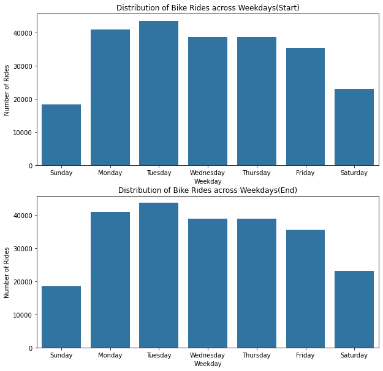

```python
## Distribution of of individual bike rides across all days of the week
base_color = sns.color_palette()[0]
days_of_week = ['Sunday', 'Monday', 'Tuesday', 'Wednesday', 'Thursday', 'Friday', 'Saturday']
dayorder = pd.api.types.CategoricalDtype(ordered=True, categories=days_of_week)
df_clean['start_dayofweek'] = df_clean['start_dayofweek'].astype(dayorder)
df_clean['end_dayofweek'] = df_clean['end_dayofweek'].astype(dayorder)

## Starting Days
plt.figure(figsize=[10,10])
plt.subplot(2,1,1)
plt.subplots_adjust(hspace=0.2)
sns.countplot(data = df_clean, x = 'start_dayofweek', color = base_color)
plt.xlabel('Weekday')
plt.ylabel('Number of Rides')
plt.title('Distribution of Bike Rides across Weekdays(Start)')

## Ending Days
plt.subplot(2,1,2)
sns.countplot(data = df_clean, x = 'end_dayofweek', color = base_color)
plt.xlabel('Weekday')
plt.ylabel('Number of Rides')
plt.title('Distribution of Bike Rides across Weekdays(End)')
```

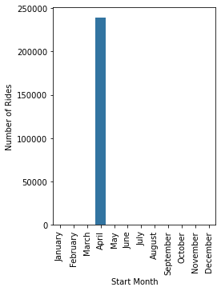

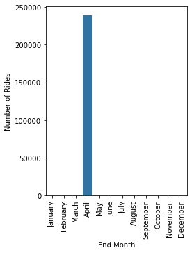

```python
## Distribution of bike rides across all months in a year
month = ['January', 'February', 'March', 'April', 'May', 'June', 'July', 'August', 'September', 'October', 'November', 'December']
month_order = pd.api.types.CategoricalDtype(ordered=True, categories=month)
df_clean['start_month'] = df_clean['start_month'].astype(month_order)
df_clean['end_month'] = df_clean['end_month'].astype(month_order)

## Plotting for starting month
plt.figure(figsize=[8,5])
plt.subplot(1,2,1)
plt.subplots_adjust(hspace=0.3)
sns.countplot(data=df_clean, x='start_month', color=base_color)
plt.xticks(rotation=90)
plt.xlabel('Start Month')
plt.ylabel('Number of Rides')

## Plotting for Ending month
plt.figure(figsize=[8,5])
plt.subplot(1,2,2)
sns.countplot(data=df_clean, x='end_month', color=base_color)
plt.xticks(rotation=90)
plt.xlabel('End Month')
plt.ylabel('Number of Rides')
```

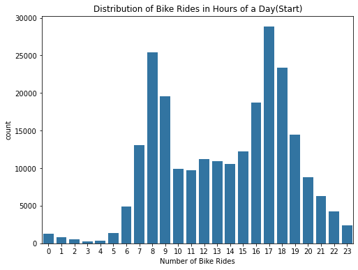

```python
## Distribution of individual bike rides across all hours of the day(Start)
plt.figure(figsize=[8,6])
sns.countplot(data = df_clean, x = 'start_hour', color = base_color)
plt.xlabel('Hour')
plt.xlabel('Number of Bike Rides')
plt.title('Distribution of Bike Rides in Hours of a Day(Start)')
```

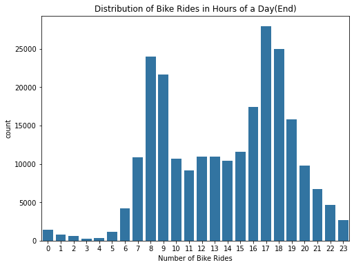

```python
## Distribution of individual bike rides across all hours of the day(End)
plt.figure(figsize=[8,6])
sns.countplot(data = df_clean, x = 'end_hour', color = base_color)
plt.xlabel('Hour')
plt.xlabel('Number of Bike Rides')
plt.title('Distribution of Bike Rides in Hours of a Day(End)')
```

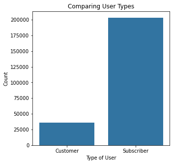

```python
## Comparing the different amount of user types
plt.figure(figsize=[5,5])
sns.countplot(data=df_clean, x='user_type', color=base_color)
plt.xlabel('Type of User')
plt.ylabel('Count')
plt.title('Comparing User Types')
```

```
(50.0, 5000.0)
```

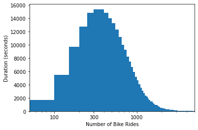

```python
## Exploring the number of bike rides based on duration
ticks = [0.1, 0.3, 1, 3, 10, 30, 100, 300, 1000]
labels = ['{}'.format(val) for val in ticks]
bin_edges = np.arange(0, df_clean['duration_sec'].max()+50, 50)
plt.hist(data = df_clean, x = 'duration_sec', bins = bin_edges)
plt.xlabel('Number of Bike Rides')
plt.ylabel('Duration (seconds)')
plt.xscale('log')
plt.xticks(ticks, labels)
plt.xlim(50,5000)
```

```python
df_clean['start_hour'].dtype
```

```
dtype('int32')
```

### Of the features you investigated, were there any unusual distributions? Did you perform any operations on the data to tidy, adjust, or change the form of the data? If so, why did you do this?

I did extract individual data from the original start and end time columns. I did this so I had more variables to test different types of distributions. The data wasn't anything unusual. More people ride bikes during the weekdays than the weekends, and more people rode during rush hours when people are going to and away from work.

## Bivariate Exploration

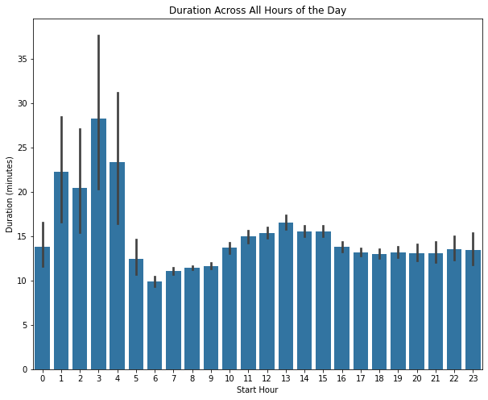

```python
## Plotting for the distribution of bike ride duration lengths across all starting hours of the day with a barplot
plt.figure(figsize=[10,8])
sns.barplot(data=df_clean, x='start_hour', y='duration_min', color=base_color)
plt.xlabel('Start Hour')
plt.ylabel('Duration (minutes)')
plt.title('Duration Across All Hours of the Day')
```

```
(0.0, 80.0)
```

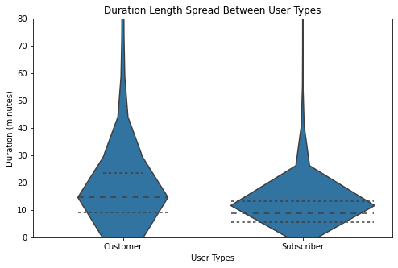

```python
## Plotting for the distribution of user types spread across various duration lengths with a violin plot
plt.figure(figsize=[8,5])
sns.violinplot(data=df_clean, x='user_type', y='duration_min', inner='quartile', color=base_color)
plt.xlabel('User Types')
plt.ylabel('Duration (minutes)')
plt.title('Duration Length Spread Between User Types')
plt.ylim(0, 80)
```

```
(0.0, 50.0)
```

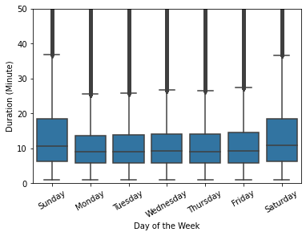

```python
##
sns.boxplot(data=df_clean, x='start_dayofweek', y='duration_min', color=base_color)
plt.xlabel('Day of the Week')
plt.ylabel('Duration (Minute)')
plt.xticks(rotation=30)
plt.ylim(0,50)
```

```
(0.0, 0.1)
```

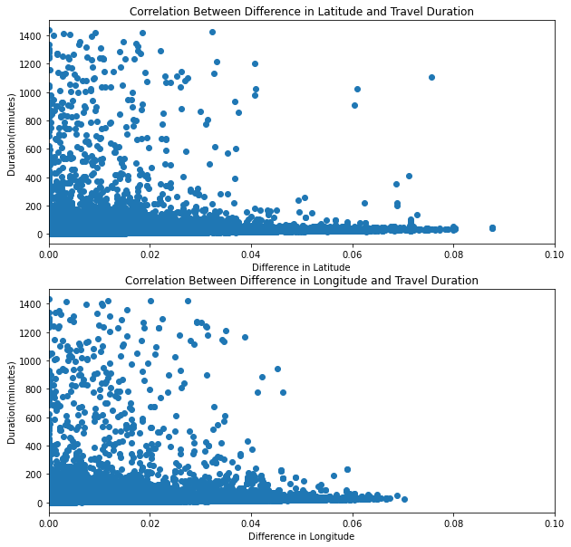

```python
## Seeing if the difference in latitude traveled correlates with duration length in minutes
df_clean['latitude_diff'] = abs(df_clean['end_station_latitude'] - df_clean['start_station_latitude'])

plt.figure(figsize=[10,10])
plt.subplot(2,1,1)
plt.subplots_adjust(hspace=0.2)
plt.scatter(data=df_clean, x='latitude_diff', y='duration_min', color=base_color)
plt.xlabel('Difference in Latitude')
plt.ylabel('Duration(minutes)')
plt.title('Correlation Between Difference in Latitude and Travel Duration')
plt.xlim(0,0.1)

## Seeing if the difference in longitude traveled correlates with duration length in minutes
df_clean['longitude_diff'] = abs(df_clean['end_station_longitude'] - df_clean['start_station_longitude'])

plt.subplot(2,1,2)
plt.scatter(data=df_clean, x='longitude_diff', y='duration_min', color=base_color)
plt.xlabel('Difference in Longitude')
plt.ylabel('Duration(minutes)')
plt.title('Correlation Between Difference in Longitude and Travel Duration')
plt.xlim(0,0.1)
```

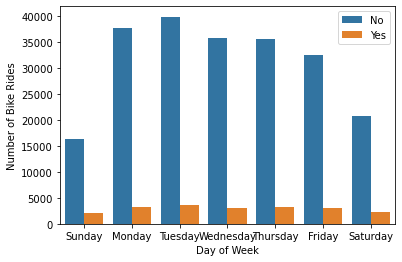

```python
## Plotting for the distribution between Yes and No answers for the bike_share_for_all_trip column across days of the week
sns.countplot(data=df_clean, x='start_dayofweek', hue='bike_share_for_all_trip');
plt.xlabel('Day of Week');
plt.ylabel('Number of Bike Rides');
plt.legend()
```

### Talk about some of the relationships you observed in this part of the investigation. How did the feature(s) of interest vary with other features in the dataset?

Something I've stated back in the univariate exploration was that it seems that most people have their bike rides during rush hours for the weekdays, but with the boxplot in the bivariate exploration I found that the medians of bike rides during the weekday is lower than that of the bike rides during the weekends.

### Did you observe any interesting relationships between the other features (not the main feature(s) of interest)?

Something interesting I've noticed is that just because the trip duration might be high, it doesn't necessary translate to a high change in starting and ending latitude or longitude. A plausible explanation may be that there may be a large amount of leisure or recreational rides and that the purpose is not meant for traveling distance. Another explanation could be that an average user did cover a reasonable distance but the net distance traveled doesn't amount to much if someone keeps riding in circles.

## Multivariate Exploration

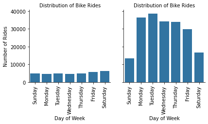

```python
## Exploring the relationship between start day, duration length, and user types
user_rank = ['Customer', 'Subscriber']
user_order = pd.api.types.CategoricalDtype(ordered=True, categories=user_rank)
df_clean['user_type'] = df_clean['user_type'].astype(user_order)

g=sns.FacetGrid(data=df_clean, col='user_type')
plt.figure(figsize=[10,8])
g.map(sns.countplot, 'start_dayofweek')
g.set_xlabels('Day of Week')
g.set_ylabels('Number of Rides')
g.set_xticklabels(rotation=90)
g.set_titles('Distribution of Bike Rides')
```

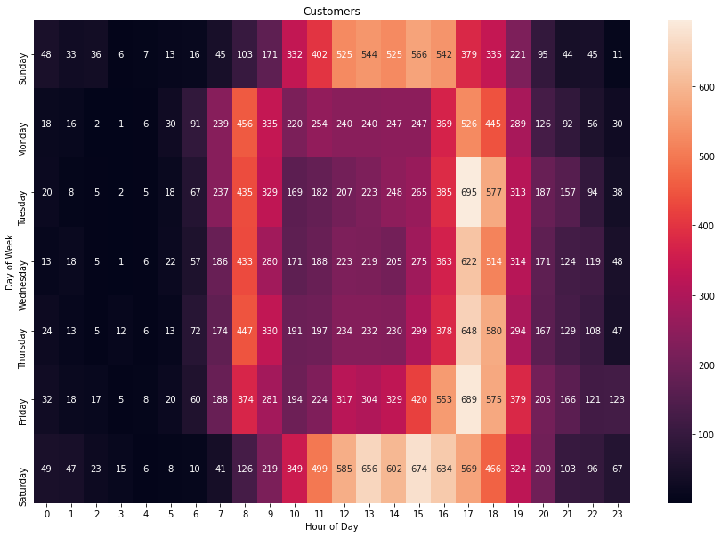

```python
plt.figure(figsize=[15,10])
customers = df_clean[df_clean['user_type'] == 'Customer']
ct_counts = customers.groupby(['start_dayofweek', 'start_hour']).size()
ct_counts = ct_counts.reset_index(name='count')
ct_counts = ct_counts.pivot(index='start_dayofweek', columns='start_hour', values='count')
sns.heatmap(ct_counts, annot=True, fmt="d")
plt.title('Customers')
plt.xlabel('Hour of Day')
plt.ylabel('Day of Week')
```

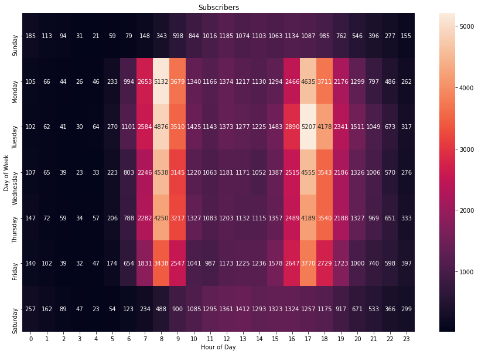

```python
plt.figure(figsize=[15,10])
subscribers = df_clean[df_clean['user_type'] == 'Subscriber']
ct_counts = subscribers.groupby(['start_dayofweek', 'start_hour']).size()
ct_counts = ct_counts.reset_index(name='count')
ct_counts = ct_counts.pivot(index='start_dayofweek', columns='start_hour', values='count')
sns.heatmap(ct_counts, annot=True, fmt="d")
plt.title('Subscribers')
plt.xlabel('Hour of Day')
plt.ylabel('Day of Week')
```

### Talk about some of the relationships you observed in this part of the investigation. Were there features that strengthened each other in terms of looking at your feature(s) of interest?

So in the multivariate exploration I mainly focused on the breakdown of the distributions of bike usage the two user types during the week. By layering different variables on top of each other, I was able to break the data down to see not only which day were more popular between the groups but also which hour in the day is most appealing to each type of user.

### Were there any interesting or surprising interactions between features?

I've noticed that while both user types share the commonality of riding bikes during rush hours of the workdays, a low percentage of the subscribers seem to continue riding during the weekends while customers seems to retain a high percentage during the weekends. We can conclude that subscribers usually use the bikes as a main source of transportation for work while customers are perhaps people who use bike as a secondary mean to get to work or people who bike around on their leisure time.